# Penguins 데이터셋 분류 (로지스틱 회귀)

## 분류 대상:

#### (1) 종류

```python
import seaborn as sns
import pandas as pd
import numpy as np

peng = sns.load_dataset('penguins')
peng.head()
```

|  | species | island | bill_length_mm | bill_depth_mm | flipper_length_mm | body_mass_g | sex |
| --- | --- | --- | --- | --- | --- | --- | --- |
| 0 | Adelie | Torgersen | 39.1 | 18.7 | 181.0 | 3750.0 | Male |
| 1 | Adelie | Torgersen | 39.5 | 17.4 | 186.0 | 3800.0 | Female |
| 2 | Adelie | Torgersen | 40.3 | 18.0 | 195.0 | 3250.0 | Female |
| 3 | Adelie | Torgersen | NaN | NaN | NaN | NaN | NaN |
| 4 | Adelie | Torgersen | 36.7 | 19.3 | 193.0 | 3450.0 | Female |

# 1. 종류별로 분류하기

### 데이터 확인하기

```python
print(pd.unique(peng['species']))
```

```
['Adelie' 'Chinstrap' 'Gentoo']
```

```python
print(peng.columns)
```

```
Index(['species', 'island', 'bill_length_mm', 'bill_depth_mm',
       'flipper_length_mm', 'body_mass_g', 'sex'],
      dtype='object')
```

```python
peng.info()
```

```
<class 'pandas.core.frame.DataFrame'>
RangeIndex: 344 entries, 0 to 343
Data columns (total 7 columns):
 #   Column             Non-Null Count  Dtype
---  ------             --------------  -----
 0   species            344 non-null    object
 1   island             344 non-null    object
 2   bill_length_mm     342 non-null    float64
 3   bill_depth_mm      342 non-null    float64
 4   flipper_length_mm  342 non-null    float64
 5   body_mass_g        342 non-null    float64
 6   sex                333 non-null    object
dtypes: float64(4), object(3)
memory usage: 18.9+ KB
```

- island와 sex는 object이므로 펭귄 종류와 연관성이 있는지를 따져본 뒤 포함 여부를 결정하기로 한다.

### 펭귄 성별과 종류 간 상관 관계가 있는지 확인하기

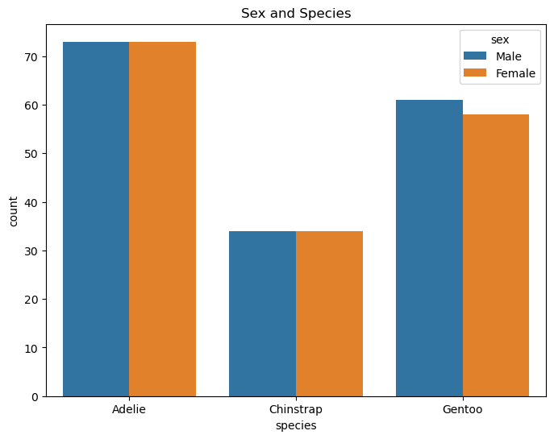

```python
import matplotlib.pyplot as plt

plt.figure(figsize=(8, 6))
sns.countplot(x='species', hue='sex', data=peng)
plt.title('Sex and Species')
plt.show()
```

- 각 종별로 성별은 고루 분포되어 있음을 알 수 있다.
- 따라서 종 분류 모델에 성별을 포함시킬 필요는 없어보인다.

### 펭귄 섬과 종류 간 상관 관계가 있는지 확인하기

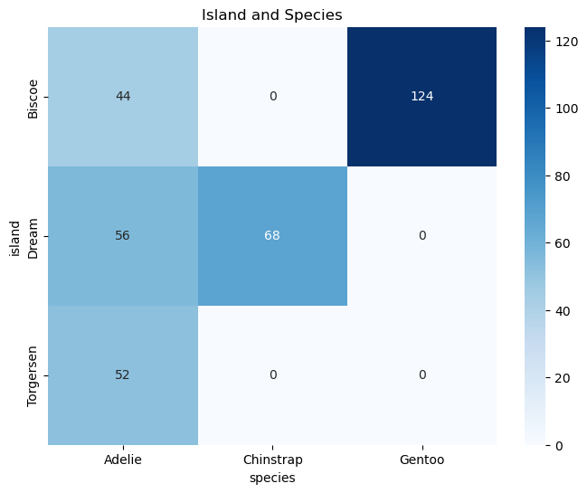

```python
plt.figure(figsize=(8, 6))
sns.heatmap(pd.crosstab(peng['island'], peng['species']), annot=True, fmt='d', cmap='Blues')
plt.title('Island and Species')
plt.show()
```

- 펭귄 섬마다 종의 분포가 각기 다름을 알 수 있다.
- 따라서 종 분류 모델링에 있어 섬 피쳐는 꼭 필요하다.

#### island 컬럼 전처리 (숫자로 매핑)

```python
from sklearn.preprocessing import LabelEncoder

label_encoder = LabelEncoder()
peng['island_no'] = label_encoder.fit_transform(peng['island'])
print(peng.groupby(['island'])['island','island_no'].head())
```

```
       island  island_no
0   Torgersen          2
1   Torgersen          2
2   Torgersen          2
3   Torgersen          2
4   Torgersen          2
20     Biscoe          0
21     Biscoe          0
22     Biscoe          0
23     Biscoe          0
24     Biscoe          0
30      Dream          1
31      Dream          1
32      Dream          1
33      Dream          1
34      Dream          1
```

#### 결측치 제거

```python
pengno = peng[peng.isna().any(axis=1)]
peng = peng.dropna()
pengno
# pengno는 추후 성별 예측을 위해 남겨둔다
```

|  | species | island | bill_length_mm | bill_depth_mm | flipper_length_mm | body_mass_g | sex | island_no |
| --- | --- | --- | --- | --- | --- | --- | --- | --- |
| 3 | Adelie | Torgersen | NaN | NaN | NaN | NaN | NaN | 2 |
| 8 | Adelie | Torgersen | 34.1 | 18.1 | 193.0 | 3475.0 | NaN | 2 |
| 9 | Adelie | Torgersen | 42.0 | 20.2 | 190.0 | 4250.0 | NaN | 2 |
| 10 | Adelie | Torgersen | 37.8 | 17.1 | 186.0 | 3300.0 | NaN | 2 |
| 11 | Adelie | Torgersen | 37.8 | 17.3 | 180.0 | 3700.0 | NaN | 2 |
| 47 | Adelie | Dream | 37.5 | 18.9 | 179.0 | 2975.0 | NaN | 1 |
| 246 | Gentoo | Biscoe | 44.5 | 14.3 | 216.0 | 4100.0 | NaN | 0 |
| 286 | Gentoo | Biscoe | 46.2 | 14.4 | 214.0 | 4650.0 | NaN | 0 |
| 324 | Gentoo | Biscoe | 47.3 | 13.8 | 216.0 | 4725.0 | NaN | 0 |
| 336 | Gentoo | Biscoe | 44.5 | 15.7 | 217.0 | 4875.0 | NaN | 0 |
| 339 | Gentoo | Biscoe | NaN | NaN | NaN | NaN | NaN | 0 |

### 훈련 데이터, 타겟 데이터 생성하기

```python
peng_input = peng[['bill_length_mm', 'bill_depth_mm','flipper_length_mm', 'body_mass_g','island_no']].to_numpy()
peng_input[:5]
```

```
array([[3.91e+01, 1.87e+01, 1.81e+02, 3.75e+03, 2.00e+00],
       [3.95e+01, 1.74e+01, 1.86e+02, 3.80e+03, 2.00e+00],
       [4.03e+01, 1.80e+01, 1.95e+02, 3.25e+03, 2.00e+00],
       [3.67e+01, 1.93e+01, 1.93e+02, 3.45e+03, 2.00e+00],
       [3.93e+01, 2.06e+01, 1.90e+02, 3.65e+03, 2.00e+00]])
```

```python
peng_target = peng['species'].to_numpy()
peng_target[:5]
```

```
array(['Adelie', 'Adelie', 'Adelie', 'Adelie', 'Adelie'], dtype=object)
```

```python
from sklearn.model_selection import train_test_split

train_input,test_input,train_target,test_target = train_test_split(peng_input,peng_target,test_size=0.3,random_state=42)
print("원본 데이터:",peng_input.shape)
print("훈련 데이터:",train_input.shape)
print("테스트 데이터:",test_input.shape)
```

```
원본 데이터: (333, 5)
훈련 데이터: (233, 5)
테스트 데이터: (100, 5)
```

### StandardScaler로 표준화하기

```python
from sklearn.preprocessing import StandardScaler

ss = StandardScaler()
ss.fit(train_input)
train_scaled = ss.transform(train_input)
test_scaled = ss.transform(test_input)
```

```python
print(train_input[:5])
print(train_scaled[:5])
```

```
[[4.050e+01 1.790e+01 1.870e+02 3.200e+03 0.000e+00]
 [4.820e+01 1.560e+01 2.210e+02 5.100e+03 0.000e+00]
 [4.740e+01 1.460e+01 2.120e+02 4.725e+03 0.000e+00]
 [3.760e+01 1.700e+01 1.850e+02 3.600e+03 0.000e+00]
 [5.280e+01 2.000e+01 2.050e+02 4.550e+03 1.000e+00]]
[[-0.68859414  0.41178581 -1.01319331 -1.22511852 -0.90893258]
 [ 0.75514402 -0.77912631  1.44365316  1.10435628 -0.90893258]
 [ 0.60514525 -1.29691419  0.79331144  0.64459151 -0.90893258]
 [-1.23233968 -0.05422328 -1.15771369 -0.73470278 -0.90893258]
 [ 1.61763696  1.49914035  0.28749011  0.43003462  0.53175648]]
```

### 로지스틱 회귀로 다중 분류하기

```python
from sklearn.linear_model import LogisticRegression

lr = LogisticRegression(max_iter=1000)
lr.fit(train_scaled, train_target)

print("훈련데이터 점수: ",lr.score(train_scaled,train_target))
print("테스트데이터 점수:",lr.score(test_scaled,test_target))
```

```
훈련데이터 점수:  0.9957081545064378
테스트데이터 점수: 0.99
```

```python
print(lr.predict(test_scaled[:6]))
print(test_target[:6])
```

```
['Adelie' 'Gentoo' 'Adelie' 'Chinstrap' 'Adelie' 'Gentoo']
['Adelie' 'Gentoo' 'Adelie' 'Chinstrap' 'Adelie' 'Gentoo']
```

#### 예측 확인

```python
decision = lr.decision_function(test_scaled[:10])
print(np.round(decision, decimals=2))
```

```
[[ 2.67  0.89 -3.56]
 [-3.27 -1.36  4.63]
 [ 3.67  0.59 -4.26]
 [-2.2   3.45 -1.25]
 [ 2.26 -0.74 -1.52]
 [-2.66 -1.56  4.21]
 [-4.54 -0.92  5.47]
 [-1.24  3.75 -2.51]
 [-1.33  3.5  -2.17]
 [-1.77  3.63 -1.86]]
```

### softmax로 확률 확인해보기

```python
from scipy.special import softmax

proba = softmax(decision, axis=1)
print(np.round(proba, decimals=3))
```

```
[[0.854 0.144 0.002]
 [0.    0.002 0.997]
 [0.956 0.044 0.   ]
 [0.004 0.987 0.009]
 [0.933 0.046 0.021]
 [0.001 0.003 0.996]
 [0.    0.002 0.998]
 [0.007 0.991 0.002]
 [0.008 0.989 0.003]
 [0.004 0.991 0.004]]
```

- 클래스 간 확률 차이도 큰 편이다. 모델 성능에 문제는 없어 보인다.

# 펭귄 종류 예측 프로그램 작성

```python
bill_length_mm = float(input("부리 길이: "))
bill_depth_mm = float(input("부리 깊이 "))
flipper_length_mm = float(input("날개 길이: "))
body_mass_g = float(input("체중: "))
island_no = int(input("섬(Biscoe:0, Dream:1, Torgersen:2): "))

user_data = np.array([[bill_length_mm, bill_depth_mm, flipper_length_mm, body_mass_g, island_no]]) # 데이터 셋업

user_data_scaled = ss.transform(user_data) # StandardScaler로 표준화

user_predict = lr.predict(user_data_scaled) # 모델로 예측

# 예측 결과 출력
print(f"예측된 품종: {user_predict[0]}")
```

```
부리 길이: 39.1
부리 깊이 18.7
날개 길이: 181
체중: 3750
섬(Biscoe:0, Dream:1, Torgersen:2): 2
예측된 품종: Adelie
```

```python
peng[:5]
```

|  | species | island | bill_length_mm | bill_depth_mm | flipper_length_mm | body_mass_g | sex | island_no |
| --- | --- | --- | --- | --- | --- | --- | --- | --- |
| 0 | Adelie | Torgersen | 39.1 | 18.7 | 181.0 | 3750.0 | Male | 2 |
| 1 | Adelie | Torgersen | 39.5 | 17.4 | 186.0 | 3800.0 | Female | 2 |
| 2 | Adelie | Torgersen | 40.3 | 18.0 | 195.0 | 3250.0 | Female | 2 |
| 4 | Adelie | Torgersen | 36.7 | 19.3 | 193.0 | 3450.0 | Female | 2 |
| 5 | Adelie | Torgersen | 39.3 | 20.6 | 190.0 | 3650.0 | Male | 2 |

# 2. 성별로 분류하기

### 펭귄 성별과 종류 간 상관 관계가 있는지 확인하기

```python
label_encoder = LabelEncoder()
peng['sex_no'] = label_encoder.fit_transform(peng['sex'])
print(peng.groupby(['sex'])['sex','sex_no'].head())
```

```
       sex  sex_no
0     Male       1
1   Female       0
2   Female       0
4   Female       0
5     Male       1
6   Female       0
7     Male       1
12  Female       0
13    Male       1
14    Male       1
```

### 성별에 따른 각 특성과의 상관관계 시각화

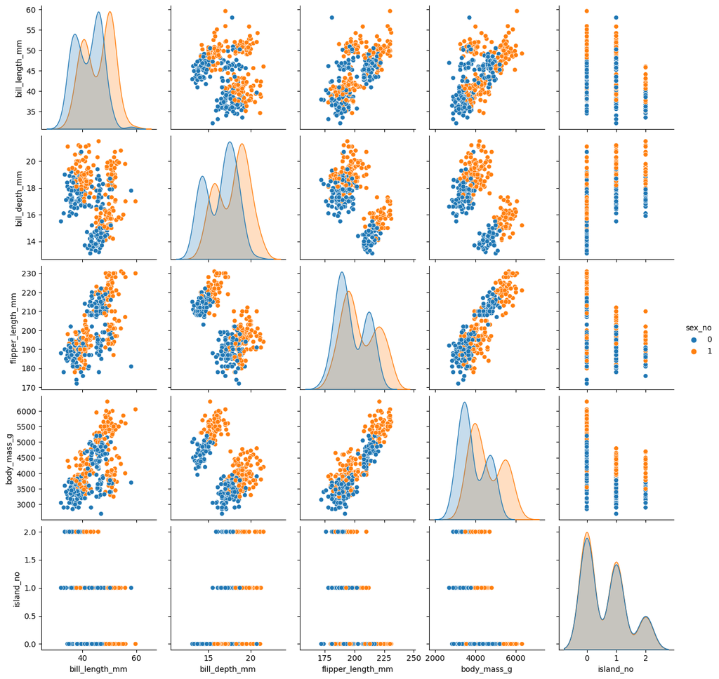

```python
import seaborn as sns
import matplotlib.pyplot as plt

peng_num = peng.select_dtypes('number')

sns.pairplot(peng_num, hue='sex_no')
plt.show()
```

### 훈련 데이터, 타겟 데이터 생성하기

```python
peng_input2 = peng[['bill_depth_mm','flipper_length_mm', 'body_mass_g']].to_numpy()
peng_input2[:5]
```

```
array([[  18.7,  181. , 3750. ],
       [  17.4,  186. , 3800. ],
       [  18. ,  195. , 3250. ],
       [  19.3,  193. , 3450. ],
       [  20.6,  190. , 3650. ]])
```

```python
peng_target2 = peng['sex'].to_numpy()
peng_target2[:5]
```

```
array(['Male', 'Female', 'Female', 'Female', 'Male'], dtype=object)
```

```python
from sklearn.model_selection import train_test_split

train_input2,test_input2,train_target2,test_target2 = train_test_split(peng_input2,peng_target2,test_size=0.3,random_state=42)
print("원본 데이터:",peng_input2.shape)
print("훈련 데이터:",train_input2.shape)
print("테스트 데이터:",test_input2.shape)
```

```
원본 데이터: (333, 3)
훈련 데이터: (233, 3)
테스트 데이터: (100, 3)
```

### StandardScaler로 표준화하기

```python
from sklearn.preprocessing import StandardScaler

ss2 = StandardScaler()
ss2.fit(train_input2)
train_scaled2 = ss2.transform(train_input2)
test_scaled2 = ss2.transform(test_input2)
```

```python
print(train_input2[:5])
print(train_scaled2[:5])
```

```
[[  17.9  187.  3200. ]
 [  15.6  221.  5100. ]
 [  14.6  212.  4725. ]
 [  17.   185.  3600. ]
 [  20.   205.  4550. ]]
[[ 0.41178581 -1.01319331 -1.22511852]
 [-0.77912631  1.44365316  1.10435628]
 [-1.29691419  0.79331144  0.64459151]
 [-0.05422328 -1.15771369 -0.73470278]
 [ 1.49914035  0.28749011  0.43003462]]
```

```python
from sklearn.linear_model import LogisticRegression

lr2 = LogisticRegression(C=5,max_iter=1000)
lr2.fit(train_scaled2, train_target2)

print("훈련데이터 점수: ",lr2.score(train_scaled2,train_target2))
print("테스트데이터 점수:",lr2.score(test_scaled2,test_target2))
```

```
훈련데이터 점수:  0.9012875536480687
테스트데이터 점수: 0.9
```

- 썩 만족스러운 스코어는 아니지만 최적치를 찾아보았다.

```python
print(lr2.predict(test_scaled2[:6]))
print(test_target2[:6])
```

```
['Female' 'Female' 'Male' 'Female' 'Male' 'Female']
['Female' 'Female' 'Male' 'Female' 'Male' 'Female']
```

- 나쁘지 않은데?

#### 예측 확인

```python
decision = lr2.decision_function(test_scaled2[:10])
print(np.round(decision,decimals=2))
```

```
[-5.82 -1.46  3.18 -2.22  1.54 -3.85  2.86  0.08  0.13  2.76]
```

### softmax로 확률 확인해보기

```python
from scipy.special import softmax

proba = softmax(decision)
print(np.round(proba, decimals=3))
```

```
[0.    0.004 0.372 0.002 0.072 0.    0.27  0.017 0.018 0.245]
```

# 펭귄 성별 예측 프로그램 작성

```python
bill_depth_mm = float(input("부리 깊이 "))
flipper_length_mm = float(input("날개 길이: "))
body_mass_g = float(input("체중: "))

user_data = np.array([[bill_depth_mm, flipper_length_mm, body_mass_g]]) # 데이터 셋업

user_data_scaled = ss2.transform(user_data) # StandardScaler로 표준화

user_predict = lr2.predict(user_data_scaled) # 모델로 예측

# 예측 결과 출력
print(f"예측된 성별: {user_predict[0]}")
```

```
부리 깊이 18.7
날개 길이: 181
체중: 3750
예측된 성별: Male
```

```python
peng.head(1)
```

|  | species | island | bill_length_mm | bill_depth_mm | flipper_length_mm | body_mass_g | sex | island_no | sex_no |
| --- | --- | --- | --- | --- | --- | --- | --- | --- | --- |
| 0 | Adelie | Torgersen | 39.1 | 18.7 | 181.0 | 3750.0 | Male | 2 | 1 |

# 성별이 NaN인 데이터의 성별 예측하기

- 아까 저장해둔 pengno를 보면, 성별만 NaN값인 행들이 대다수이다. 위에서 만든 모델로 이 데이터들의 결측치를 채울 수 있겠다.

```python
pengno
```

|  | species | island | bill_length_mm | bill_depth_mm | flipper_length_mm | body_mass_g | sex | island_no |
| --- | --- | --- | --- | --- | --- | --- | --- | --- |
| 3 | Adelie | Torgersen | NaN | NaN | NaN | NaN | NaN | 2 |
| 8 | Adelie | Torgersen | 34.1 | 18.1 | 193.0 | 3475.0 | NaN | 2 |
| 9 | Adelie | Torgersen | 42.0 | 20.2 | 190.0 | 4250.0 | NaN | 2 |
| 10 | Adelie | Torgersen | 37.8 | 17.1 | 186.0 | 3300.0 | NaN | 2 |
| 11 | Adelie | Torgersen | 37.8 | 17.3 | 180.0 | 3700.0 | NaN | 2 |
| 47 | Adelie | Dream | 37.5 | 18.9 | 179.0 | 2975.0 | NaN | 1 |
| 246 | Gentoo | Biscoe | 44.5 | 14.3 | 216.0 | 4100.0 | NaN | 0 |
| 286 | Gentoo | Biscoe | 46.2 | 14.4 | 214.0 | 4650.0 | NaN | 0 |
| 324 | Gentoo | Biscoe | 47.3 | 13.8 | 216.0 | 4725.0 | NaN | 0 |
| 336 | Gentoo | Biscoe | 44.5 | 15.7 | 217.0 | 4875.0 | NaN | 0 |
| 339 | Gentoo | Biscoe | NaN | NaN | NaN | NaN | NaN | 0 |

- 예측에 필요한 값만 빼내자

```python
pengno_s=pengno.iloc[1:-1,3:6]
pengno_s
```

|  | bill_depth_mm | flipper_length_mm | body_mass_g |
| --- | --- | --- | --- |
| 8 | 18.1 | 193.0 | 3475.0 |
| 9 | 20.2 | 190.0 | 4250.0 |
| 10 | 17.1 | 186.0 | 3300.0 |
| 11 | 17.3 | 180.0 | 3700.0 |
| 47 | 18.9 | 179.0 | 2975.0 |
| 246 | 14.3 | 216.0 | 4100.0 |
| 286 | 14.4 | 214.0 | 4650.0 |
| 324 | 13.8 | 216.0 | 4725.0 |
| 336 | 15.7 | 217.0 | 4875.0 |

```python
pengno_s_scaled = ss2.transform(pengno_s) # StandardScaler로 표준화

pred_pengno_s = lr2.predict(pengno_s_scaled) # 모델로 예측
print(pred_pengno_s)
```

```
['Female' 'Male' 'Female' 'Female' 'Female' 'Female' 'Female' 'Female'
 'Male']
```

```python
pengno_s['sex'] = pred_pengno_s
pengno_s
```

|  | bill_depth_mm | flipper_length_mm | body_mass_g | sex |
| --- | --- | --- | --- | --- |
| 8 | 18.1 | 193.0 | 3475.0 | Female |
| 9 | 20.2 | 190.0 | 4250.0 | Male |
| 10 | 17.1 | 186.0 | 3300.0 | Female |
| 11 | 17.3 | 180.0 | 3700.0 | Female |
| 47 | 18.9 | 179.0 | 2975.0 | Female |
| 246 | 14.3 | 216.0 | 4100.0 | Female |
| 286 | 14.4 | 214.0 | 4650.0 | Female |
| 324 | 13.8 | 216.0 | 4725.0 | Female |
| 336 | 15.7 | 217.0 | 4875.0 | Male |

- 이제 위 데이터를 로우 데이터에 update하면 더 완성도 있는 데이터로 활용할 수 있을 것이다. (노가다의 최종 목적지가 결국 또 전처리였다니...)